# Intro to Conjoint Experiments | Solutions - 4

# 1 Environment preparation

```r
# ### Data import ###
# install.packages("readr")     # read datasets
# install.packages("qualtRics") # read qualtrics datasets
# ### Data manipulation ###
# install.packages("dplyr")     # pipes and data manipulation
# ### Visualization ###
# install.packages("ggplot2")    # graphing capabilities
# ### Estimation ###
# install.packages("cjoint")    # base amce package
# install.packages("cregg")     # amce and mm
# install.packages("factorEx")  # amce with non-uniform distribution

## Custom build functions
# library(devtools)
# install_github("albertostefanelli/cjoint") # fixes some problem with cjoint

### Data import ###
library("readr")
library("qualtRics")
### Data manipulation ###
library("dplyr")
### Visualization ###
library("ggplot2")
### Estimation ###
library("cjoint")
library("cregg")
library("factorEx")
```

# 2 Data

1. From the paper “The Ties that Double Bind” [@teele_ties_2018]
2. We are going to use the Legislators and Voters sample
3. The authors want to test different type of gender biases
   - Among Legislators
   - Among Voters

| Attribute | Values |
| --- | --- |
| Gender | Female, Male |
| Age | 29, 45, 65 |
| Number of Children | 0, 1, 3 |
| Highest Elected Political Post | None, Mayor, State Legislator |
| Occupation | Corporate Lawyer, Third Grade Teacher |
| Spouse’s Occupation | Doctor, Farmer, Unmarried |

- Variables in the dataset
  - CJ choice task= “winner”
  - Type of sample = “sample”
  - Respondent’s gender=“female_respondent”
  - Respondent’s PID= “democrat_respondent”, “republican_respondent”
  - Candidate’s gender= “orig_cand_female”
  - Candidate’s political Experience= “orig_0ys”, “orig_1ys”, “orig_3ys”, “orig_8ys”
  - Candidate’s number of Children= “orig_0ch”, “orig_1ch”, “orig_3ch”
  - Candidate’s political Post= “orig_may”, “orig_leg”
  - Candidate’s occupation= “orig_law”, “orig_teach”
  - Candidate’s spouse’s Occupation= “orig_UN_sp”, “orig_FM_sp”, “orig_MD_sp”
  - Candidate’s candidate’s Age= “orig_29”, “orig_45”, orig_65”

# 3 Task

```r
# load the data
teele_data <- readr::read_csv("https://github.com/albertostefanelli/conjoint_class/raw/master/data/teele.csv")
```

# 4 Hypothesises

Let’s first postulate some hypotheses - H1 There will be bias towards female candidates among legislators - H2 Voters will be more biased towards female candidates compared to legislators

Let’s estimate the AMCE for using the Teele Data.

```r
# subset only legislators
data_teele_legislator <- subset(teele_data, sample == "usa leg")
# since there run a replication sample 2 years later, we are going to subset only the observations of the original sample
data_teele_legislator <- subset(data_teele_legislator, replication == 0)
# let's now tranform all the variables related to the conjoint table into factor
# they all start with c_ so it is easy to select them with the starts_with function
data_teele_legislator <- data_teele_legislator %>% mutate_at(vars(starts_with("c_")),as.factor)

# run the amce and take into account the clustering
amce_leg <- cjoint::amce(winner ~
     c_gender +
     c_experience+
     c_childern+
     c_occupation+
     c_age+
     c_spouse_occupation,
     data = data_teele_legislator,
     cluster=TRUE,
     respondent.id="responseid")

summary(amce_leg)
```

```
------------------------------------------
Average Marginal Component Effects (AMCE):
------------------------------------------
           Attribute      Level   Estimate Std. Err  z value                      Pr(>|z|)
               c_age    orig_45  0.1191998 0.017471  6.82254 0.000000000008944526839713899 ***
               c_age    orig_65  0.0116339 0.017662  0.65870 0.510085547177984599542810429
          c_childern   orig_1ch  0.0276104 0.017153  1.60963 0.107478295579967533801557522
          c_childern   orig_3ch  0.0460681 0.017693  2.60377 0.009220494196750557772124246  **
        c_experience   orig_1ys  0.0603019 0.019338  3.11836 0.001818586954513476362446656  **
        c_experience   orig_3ys  0.1122188 0.019946  5.62602 0.000000018441200344363898685 ***
        c_experience   orig_8ys  0.2033479 0.019884 10.22661 0.000000000000000000000001507 ***
            c_gender       Male -0.1132854 0.013724 -8.25464 0.000000000000000152363227444 ***
        c_occupation   orig_leg  0.1328681 0.021078  6.30373 0.000000000290562709004696275 ***
        c_occupation   orig_may  0.1330060 0.020849  6.37948 0.000000000177685104558412390 ***
        c_occupation orig_teach  0.0328676 0.020843  1.57689 0.114820297273734925336263757
 c_spouse_occupation orig_MD_sp  0.0093609 0.017165  0.54534 0.585522763573905091760707364
 c_spouse_occupation orig_UN_sp -0.0750997 0.017578 -4.27228 0.000019348803701406067507814 ***
---
Number of Obs. = 4809
---
Number of Respondents = 830
---
Signif. codes: 0 '***' 0.001 '**' 0.01 '*' 0.05

--------------------
AMCE Baseline Levels:
--------------------
           Attribute      Level
               c_age    orig_29
          c_childern   orig_0ch
        c_experience   orig_0ys
            c_gender     Female
        c_occupation   orig_law
 c_spouse_occupation orig_FM_sp
```

# 5 OLS

Let’s now run a simple regression model and see what happens.

```r
lm_leg <- lm(winner ~
     c_gender +
     c_experience+
     c_childern+
     c_occupation+
     c_age+
     c_spouse_occupation,
     data = data_teele_legislator)

summary(lm_leg)
```

```
Call:
lm(formula = winner ~ c_gender + c_experience + c_childern +
    c_occupation + c_age + c_spouse_occupation, data = data_teele_legislator)

Residuals:
    Min      1Q  Median      3Q     Max
-0.8548 -0.4656 -0.1556  0.4688  0.8444

Coefficients:
                               Estimate Std. Error t value             Pr(>|t|)
(Intercept)                    0.343970   0.025970  13.245 < 0.0000000000000002 ***
c_genderMale                  -0.113285   0.013971  -8.108 0.000000000000000645 ***
c_experienceorig_1ys           0.060302   0.019571   3.081              0.00207 **
c_experienceorig_3ys           0.112219   0.019833   5.658 0.000000016177143969 ***
c_experienceorig_8ys           0.203348   0.019968  10.184 < 0.0000000000000002 ***
c_childernorig_1ch             0.027610   0.017183   1.607              0.10816
c_childernorig_3ch             0.046068   0.016984   2.712              0.00670 **
c_occupationorig_leg           0.132868   0.020066   6.622 0.000000000039416770 ***
c_occupationorig_may           0.133006   0.019614   6.781 0.000000000013365769 ***
c_occupationorig_teach         0.032868   0.019806   1.659              0.09709 .
c_ageorig_45                   0.119200   0.017134   6.957 0.000000000003945701 ***
c_ageorig_65                   0.011634   0.017057   0.682              0.49522
c_spouse_occupationorig_MD_sp  0.009361   0.017157   0.546              0.58537
c_spouse_occupationorig_UN_sp -0.075100   0.016971  -4.425 0.000009852495881359 ***
---
Signif. codes:  0 '***' 0.001 '**' 0.01 '*' 0.05 '.' 0.1 ' ' 1

Residual standard error: 0.4838 on 4795 degrees of freedom
Multiple R-squared:  0.06647,   Adjusted R-squared:  0.06394
F-statistic: 26.26 on 13 and 4795 DF,  p-value: < 0.00000000000000022
```

The coefficients are close to equivalence but the SE are off. The reason lies in the fact that with a simple OLS model we are not taking into account the clustering structure of the data (tasks nested into individuals)

# 6 Estimate the AMCE in the voter sample and test for differecnes

Let’s turn to H2 and see if there is any difference between legislators and voters.

```r
# all the same apart from the fact that in the first line we are selecting the voter sample
data_teele_voters <- subset(teele_data, sample == "usa voter")
data_teele_voters <- subset(data_teele_voters, replication == 0)
data_teele_voters <- data_teele_voters %>% mutate_at(vars(starts_with("c_")),as.factor)

amce_voters <- cjoint::amce(winner ~
     c_gender +
     c_experience+
     c_childern+
     c_occupation+
     c_age+
     c_spouse_occupation,
     data = data_teele_voters,
     cluster=TRUE,
     respondent.id="responseid")

summary(amce_voters)
```

```
------------------------------------------
Average Marginal Component Effects (AMCE):
------------------------------------------
           Attribute      Level  Estimate Std. Err z value                    Pr(>|z|)
               c_age    orig_45  0.079860 0.012785  6.2463 0.0000000004203753528861278 ***
               c_age    orig_65 -0.015161 0.013045 -1.1621 0.2451765185619938502981086
          c_childern   orig_1ch  0.048990 0.012116  4.0434 0.0000526737852545948776633 ***
          c_childern   orig_3ch  0.054861 0.012598  4.3548 0.0000133213005752185708306 ***
        c_experience   orig_1ys  0.049014 0.014335  3.4191 0.0006281947593469323345636 ***
        c_experience   orig_3ys  0.105694 0.014323  7.3791 0.0000000000001593361927449 ***
        c_experience   orig_8ys  0.142990 0.015162  9.4311 0.0000000000000000000040574 ***
            c_gender       Male -0.025756 0.010045 -2.5640 0.0103475032897011685190103   *
        c_occupation   orig_leg  0.119391 0.014617  8.1680 0.0000000000000003134994198 ***
        c_occupation   orig_may  0.128003 0.014626  8.7516 0.0000000000000000021035621 ***
        c_occupation orig_teach  0.073254 0.015124  4.8435 0.0000012760178772428103475 ***
 c_spouse_occupation orig_MD_sp -0.031411 0.012152 -2.5848 0.0097425719377280117772244  **
 c_spouse_occupation orig_UN_sp -0.093006 0.012788 -7.2727 0.0000000000003523689437107 ***
---
Number of Obs. = 9790
---
Number of Respondents = 1653
---
Signif. codes: 0 '***' 0.001 '**' 0.01 '*' 0.05

--------------------
AMCE Baseline Levels:
--------------------
           Attribute      Level
               c_age    orig_29
          c_childern   orig_0ch
        c_experience   orig_0ys
            c_gender     Female
        c_occupation   orig_law
 c_spouse_occupation orig_FM_sp
```

```r
# let's test difference in AGE 45 VS AGE 29
d<-amce_leg$estimates$cage["AMCE",][1] - amce_voters$estimates$cage["AMCE",][1]
var_leg<-amce_leg$estimates$cage["Std. Error",][1]^2
var_voter<-amce_voters$estimates$cage["Std. Error",][1]^2

ztest<- d / sqrt(var_leg+var_voter)
1-pnorm(ztest)
```

```
cageorig45
0.03460026
```

```r
ifelse(1-pnorm(ztest) <0.05, "There are differences", "No differences")
```

```
             cageorig45
"There are differences"
```

# 7 Plotting

[figure not shown]

```r
plot(amce_leg) +  scale_colour_grey(start = 0, end = .5) +
  theme_bw() + theme(text = element_text(size=18)) +
    theme(legend.position = "none")
```

# 8 Fatigue

Let’s now take a look at the effect of task on selecting a profile. We might expect that people got tired with the progression of the experiment and as such, we would see an effect of task numbering on their response behaviour. Again, we want the coefficients to overlap to have no significant different between tasks.

```r
data_teele_legislator$contest <- as.factor(data_teele_legislator$contest)

fit_fatigue <- cregg::cj(data_teele_legislator, winner ~
     c_gender +
     c_experience+
     c_childern+
     c_occupation+
     c_age+
     c_spouse_occupation,
     id = ~responseid,
     by = ~contest,
     estimate = "mm")
```

Let’s now take a look at the effect of task on selecting a profile. We might expect that people got tired with the progression of the experiment and as such, we would see an effect of task numbering on their response behaviour. Again, we want the coefficients to overlap to have no significant different between tasks.

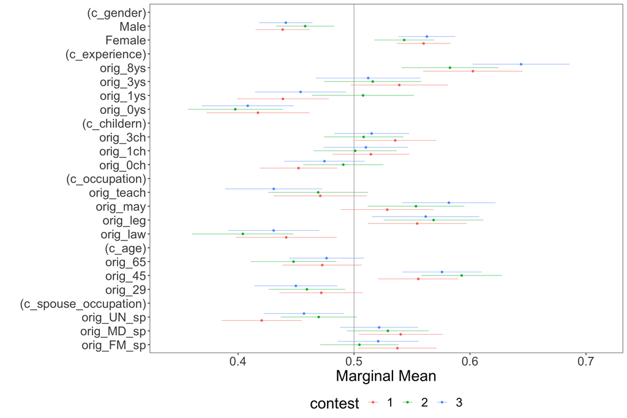

```r
plot(fit_fatigue,
  group = "contest", vline = 0.5) +
  theme(text = element_text(size=21))
```